# Credit Category classification

Piotr Wieczorek

2024-02-19

```r
rm(list=ls())
```

## Goal of the project

#### This project aims to classify clients based on a set of attributes as associated good or bad credit risks.

## Libraries

```r
library(tidyverse)
library(caret)
library(stats)
library(MLmetrics)
library(sjPlot)
library(rcompanion)
library(kableExtra)
library(lmtest)
library(janitor)
library(ggthemr)
library(gridExtra)
library(modelsummary)
```

## Reading and cleaning the data

```r
df <- read.csv("bank.csv")
```

```r
head(df) %>%
  kable(align = "c") %>%
    kable_styling(position = "center") %>%
    scroll_box(width = "100%")
```

| X | checking_status | duration | credit_history | purpose | credit_amount | savings_status | employment | installment_commitment | personal_status | other_parties | residence_since | property_magnitude | age | other_payment_plans | housing | existing_credits | job | num_dependents | own_telephone | foreign_worker | class |
| --- | --- | --- | --- | --- | --- | --- | --- | --- | --- | --- | --- | --- | --- | --- | --- | --- | --- | --- | --- | --- | --- |
| 0 | <0 | 6 | critical/other existing credit | radio/tv | 1169 | no known savings | >=7 | 4 | male single | none | 4 | real estate | 67 | none | own | 2 | skilled | 1 | yes | yes | good |
| 1 | 0<=X<200 | 48 | existing paid | radio/tv | 5951 | <100 | 1<=X<4 | 2 | female div/dep/mar | none | 2 | real estate | 22 | none | own | 1 | skilled | 1 | none | yes | bad |
| 2 | no checking | 12 | critical/other existing credit | education | 2096 | <100 | 4<=X<7 | 2 | male single | none | 3 | real estate | 49 | none | own | 1 | unskilled resident | 2 | none | yes | good |
| 3 | <0 | 42 | existing paid | furniture/equipment | 7882 | <100 | 4<=X<7 | 2 | male single | guarantor | 4 | life insurance | 45 | none | for free | 1 | skilled | 2 | none | yes | good |
| 4 | <0 | 24 | delayed previously | new car | 4870 | <100 | 1<=X<4 | 3 | male single | none | 4 | no known property | 53 | none | for free | 2 | skilled | 2 | none | yes | bad |
| 5 | no checking | 36 | existing paid | education | 9055 | no known savings | 1<=X<4 | 2 | male single | none | 4 | no known property | 35 | none | for free | 1 | unskilled resident | 2 | yes | yes | good |

```r
df <- df %>%
  select(-c("X")) %>%
  mutate(across(where(is.character),as.factor))
```

```r
df <- df %>%
  mutate(across(c("residence_since","existing_credits"),as.factor))
```

## Exploratory analysis

#### The plot below pictures share of independent variables’ categories by the risk class

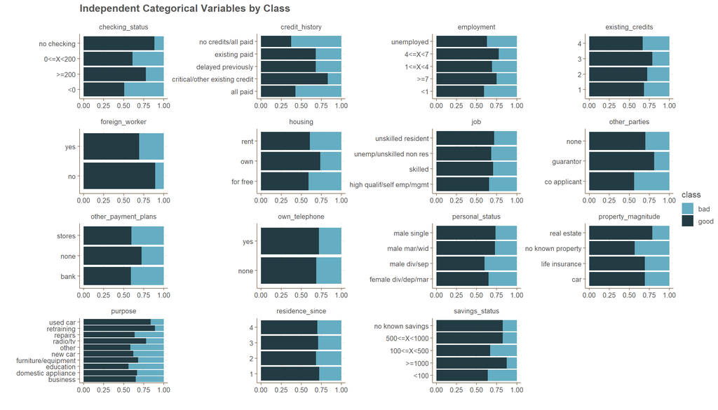

```r
ggthemr("fresh")

df %>%
  gather(c("checking_status","credit_history","purpose","savings_status",
           "employment","personal_status","other_parties","property_magnitude",
           "other_payment_plans","housing","job","own_telephone","foreign_worker",
           "existing_credits","residence_since"),
            value="val",key="key") %>%
  count(key,val,class) %>%
  ggplot(aes(x=val,y=n,fill=class)) +
  geom_bar(stat="identity",position = position_fill()) +
  facet_wrap(~key,scales="free") +
  #theme_bw() +
  coord_flip() +
  labs(x="",y="",title = "Independent Categorical Variables by Class")
```

## Modeling

### Data partition

```r
set.seed(321)

data_partition <- caret::createDataPartition(df$class,p=0.7,list=FALSE)

train_set <- df[data_partition,]
test_set <- df[-data_partition,]
```

### First model

```r
mod1 <- glm(formula = class ~., data = train_set, family = "binomial")
```

```r
tab_model(mod1,show.ci = 0.95,p.style="stars",p.threshold = c(0.1, 0.05, 0.01),show.aic = TRUE,
          show.loglik = TRUE)
```

class

Predictors

Odds Ratios

CI

(Intercept)

8.32

0.46 – 181.48

checking status [>=200]

4.12 ***

1.57 – 11.94

checking status  
[0<=X<200]

1.31

0.78 – 2.20

checking status [no  
checking]

6.83 ***

3.96 – 12.07

duration

0.98

0.96 – 1.01

credit history  
[critical/other existing  
credit]

4.19 ***

1.48 – 12.38

credit history [delayed  
previously]

2.20

0.70 – 7.16

credit history [existing  
paid]

1.24

0.49 – 3.25

credit history [no  
credits/all paid]

0.77

0.20 – 3.03

purpose [domestic  
appliance]

0.55

0.11 – 3.01

purpose [education]

0.31 **

0.09 – 0.98

purpose  
[furniture/equipment]

0.61

0.27 – 1.35

purpose [new car]

0.37 **

0.17 – 0.78

purpose [other]

1.69

0.27 – 12.40

purpose [radio/tv]

1.01

0.45 – 2.20

purpose [repairs]

0.60

0.15 – 2.54

purpose [retraining]

2.49

0.27 – 57.14

purpose [used car]

3.16 **

1.06 – 10.19

credit amount

1.00 **

1.00 – 1.00

savings status [>=1000]

3.08 *

0.97 – 12.10

savings status  
[100<=X<500]

0.87

0.44 – 1.75

savings status  
[500<=X<1000]

1.37

0.53 – 3.99

savings status [no known  
savings]

2.16 **

1.20 – 4.02

employment [>=7]

1.28

0.63 – 2.59

employment [1<=X<4]

1.14

0.63 – 2.06

employment [4<=X<7]

1.80

0.88 – 3.75

employment [unemployed]

1.81

0.65 – 5.13

installment commitment

0.75 ***

0.60 – 0.92

personal status [male  
div/sep]

0.70

0.29 – 1.72

personal status [male  
mar/wid]

0.68

0.31 – 1.49

personal status [male  
single]

1.37

0.82 – 2.30

other parties [guarantor]

5.10 **

1.25 – 22.68

other parties [none]

1.37

0.48 – 3.88

residence since [2]

0.54 *

0.27 – 1.06

residence since [3]

0.70

0.32 – 1.49

residence since [4]

0.73

0.36 – 1.45

property magnitude [life  
insurance]

0.96

0.55 – 1.65

property magnitude [no  
known property]

0.48

0.19 – 1.23

property magnitude [real  
estate]

1.49

0.83 – 2.71

age

1.02

0.99 – 1.04

other payment plans  
[none]

1.86 **

1.05 – 3.27

other payment plans  
[stores]

1.64

0.60 – 4.61

housing [own]

0.83

0.28 – 2.42

housing [rent]

0.59

0.18 – 1.84

existing credits [2]

0.39 ***

0.21 – 0.68

existing credits [3]

0.50

0.12 – 2.45

existing credits [4]

0.66

0.04 – 18.72

job [skilled]

1.09

0.55 – 2.12

job [unemp/unskilled non  
res]

2.10

0.36 – 14.59

job [unskilled resident]

1.10

0.47 – 2.56

num dependents

0.88

0.48 – 1.63

own telephone [yes]

1.18

0.73 – 1.90

foreign worker [yes]

0.18 **

0.03 – 0.75

Observations

700

R<sup>2</sup> Tjur

0.319

AIC

721.124

log-Likelihood

-307.562

- p<0.1 ** p<0.05 *** p<0.01

### Second model

```r
mod2 <- glm(formula = class ~. -job -existing_credits -num_dependents -property_magnitude -housing -employment, data = train_set, family = "binomial")
```

```r
tab_model(mod2,show.ci = 0.95,p.style="stars",show.aic = TRUE,
          show.loglik = TRUE,p.threshold = c(0.1,0.05,0.01))
```

class

Predictors

Odds Ratios

CI

(Intercept)

6.93

0.75 – 84.71

checking status [>=200]

3.96 ***

1.56 – 11.18

checking status  
[0<=X<200]

1.35

0.82 – 2.22

checking status [no  
checking]

6.06 ***

3.59 – 10.40

duration

0.98

0.96 – 1.01

credit history  
[critical/other existing  
credit]

2.69 **

1.05 – 7.05

credit history [delayed  
previously]

1.40

0.49 – 4.11

credit history [existing  
paid]

1.35

0.55 – 3.35

credit history [no  
credits/all paid]

0.44

0.13 – 1.54

purpose [domestic  
appliance]

0.63

0.13 – 3.29

purpose [education]

0.24 **

0.08 – 0.73

purpose  
[furniture/equipment]

0.59

0.27 – 1.29

purpose [new car]

0.34 ***

0.16 – 0.71

purpose [other]

1.33

0.23 – 8.68

purpose [radio/tv]

0.97

0.45 – 2.05

purpose [repairs]

0.58

0.16 – 2.33

purpose [retraining]

2.93

0.33 – 65.13

purpose [used car]

2.46 *

0.87 – 7.47

credit amount

1.00 **

1.00 – 1.00

savings status [>=1000]

3.06 *

1.00 – 11.69

savings status  
[100<=X<500]

0.83

0.44 – 1.60

savings status  
[500<=X<1000]

1.47

0.59 – 4.14

savings status [no known  
savings]

2.13 **

1.20 – 3.89

installment commitment

0.74 ***

0.60 – 0.91

personal status [male  
div/sep]

0.70

0.30 – 1.67

personal status [male  
mar/wid]

0.76

0.36 – 1.64

personal status [male  
single]

1.40

0.87 – 2.25

other parties [guarantor]

6.00 **

1.58 – 24.78

other parties [none]

1.52

0.57 – 4.03

residence since [2]

0.50 **

0.26 – 0.95

residence since [3]

0.67

0.32 – 1.40

residence since [4]

0.63

0.33 – 1.18

age

1.02 *

1.00 – 1.04

other payment plans  
[none]

2.01 **

1.16 – 3.47

other payment plans  
[stores]

1.72

0.65 – 4.66

own telephone [yes]

1.16

0.76 – 1.78

foreign worker [yes]

0.17 **

0.02 – 0.67

Observations

700

R<sup>2</sup> Tjur

0.295

AIC

712.554

log-Likelihood

-319.277

- p<0.1 ** p<0.05 *** p<0.01

### Models comparison - Likelihood ratio test

```r
lrtest(mod1,mod2)
```

```
## Likelihood ratio test
##
## Model 1: class ~ checking_status + duration + credit_history + purpose +
##     credit_amount + savings_status + employment + installment_commitment +
##     personal_status + other_parties + residence_since + property_magnitude +
##     age + other_payment_plans + housing + existing_credits +
##     job + num_dependents + own_telephone + foreign_worker
## Model 2: class ~ (checking_status + duration + credit_history + purpose +
##     credit_amount + savings_status + employment + installment_commitment +
##     personal_status + other_parties + residence_since + property_magnitude +
##     age + other_payment_plans + housing + existing_credits +
##     job + num_dependents + own_telephone + foreign_worker) -
##     job - existing_credits - num_dependents - property_magnitude -
##     housing - employment
##   #Df  LogLik  Df Chisq Pr(>Chisq)
## 1  53 -307.56
## 2  37 -319.28 -16 23.43     0.1027
```

#### Conclusion: There is no significant difference between these models, so it’s better to choose the least complicated one (with less variables)

### Coefficient plot

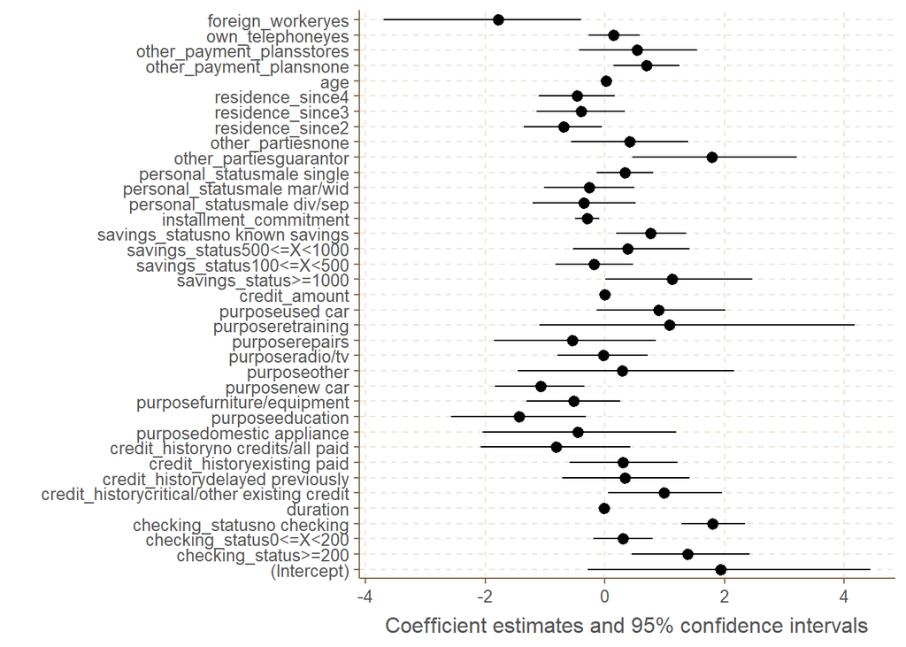

```r
modelplot(mod2)
```

### Variables’ effect on the prediction

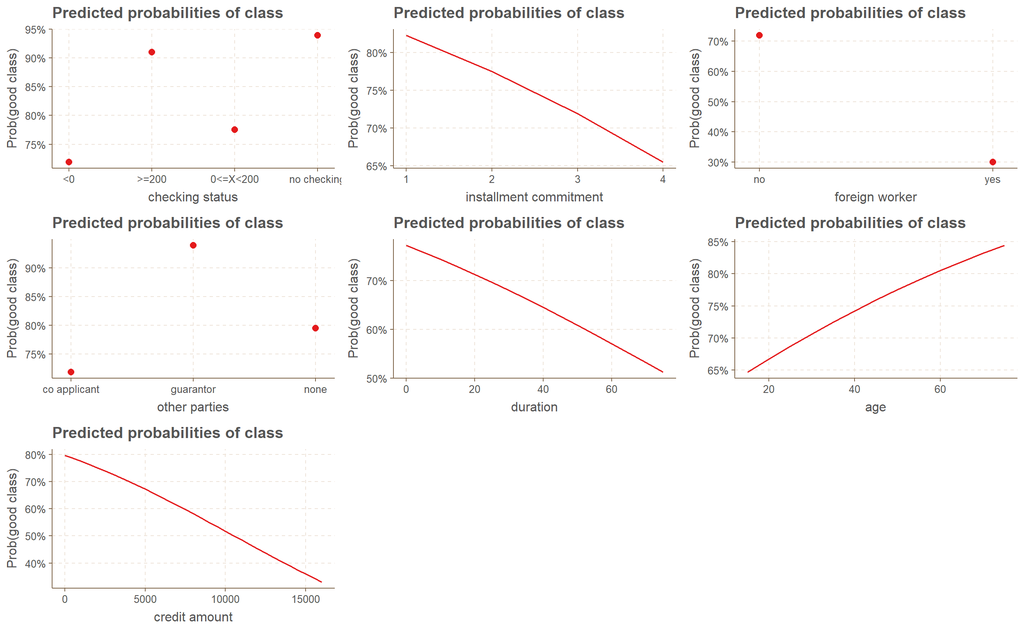

```r
grid.arrange(
  plot_model(mod2,
  type = "pred",
  terms = c("checking_status"),
  ci.lvl = NA # remove confidence bands
) +
  labs(y = "Prob(good class)"),

  plot_model(mod2,
             type="pred",
             terms=c("installment_commitment"),
             ci.lvl=NA)+
  labs(y = "Prob(good class)"),

 plot_model(mod2,
             type="pred",
             terms=c("foreign_worker"),
             ci.lvl=NA)+
  labs(y = "Prob(good class)"),

plot_model(mod2,
             type="pred",
             terms=c("other_parties"),
             ci.lvl=NA)+
  labs(y = "Prob(good class)"),

plot_model(mod2,
             type="pred",
             terms=c("duration"),
             ci.lvl=NA)+
  labs(y = "Prob(good class)"),

plot_model(mod2,
             type="pred",
             terms=c("age"),
             ci.lvl=NA)+
  labs(y = "Prob(good class)"),

plot_model(mod2,
             type="pred",
             terms=c("credit_amount"),
             ci.lvl=NA)+
  labs(y = "Prob(good class)")

)
```

#### Conclusion:

1. As age increases, the more likely it is to be classified as the “good” risk class
2. As credit amount increases, the less likely it is to be classified as the “good” risk class
3. As duration increases, the less likely it is to be classified as the “good” risk class
4. As the install commitment increases, the less likely it is to be classified as the “good” risk class
5. As the credit amount increases, the less likely it is to be classified as the “good” risk class
6. Foreign workers are less likely to be classified as the “good” risk class
7. Guarantors are more likely to be classified as the “good” risk class

### Prediction

```r
test_pred <- predict(mod2,test_set,type="response")
```

```r
test_pred <- as.factor(ifelse(test_pred >=0.5,"good","bad"))
```

### Confusion matrix

```r
confusionMatrix(test_pred, test_set$class,positive = "good")
```

```
## Confusion Matrix and Statistics
##
##           Reference
## Prediction bad good
##       bad   52   35
##       good  38  175
##
##                Accuracy : 0.7567
##                  95% CI : (0.704, 0.8041)
##     No Information Rate : 0.7
##     P-Value [Acc > NIR] : 0.01741
##
##                   Kappa : 0.4151
##
##  Mcnemar's Test P-Value : 0.81492
##
##             Sensitivity : 0.8333
##             Specificity : 0.5778
##          Pos Pred Value : 0.8216
##          Neg Pred Value : 0.5977
##              Prevalence : 0.7000
##          Detection Rate : 0.5833
##    Detection Prevalence : 0.7100
##       Balanced Accuracy : 0.7056
##
##        'Positive' Class : good
##
```